# Dissecting individual LD blocks using partial correlation/multiple regression

Regina H. Reynolds

UCL

> Aim: run partial correlations and multiple regression on select LD blocks

# 1 Background

Given that bivariate local $r_{g}$ analyses revealed several LD blocks where significant $r_{g}$'s were found between multiple trait pairs, we followed up with partial local $r_{g}$ analyses and multiple regression to obtain conditional genetic associations.

# 2 Methods

## 2.1 Partial correlations

For LD blocks with >= 2 significant bivariate results between the three neuropsychiatric phenotypes, we hypothesised that a shared genetic signal with a third neuropsychiatric phenotype could account for some of the overlap between two neuropyschiatric phenotypes (e.g. local $r_{g}$ between BIP and SCZ could be partially accounted for by a shared genetic signal with MDD). Thus, we used partial correlations to compute the partial genetic correlation between two phenotypes while accounting for the third.

## 2.2 Multiple regression

For select LD blocks with significant bivariate results between a phenotype and at least 2 others, multiple regression was used to determine the extent to which the genetic component of the outcome phenotype could be explained by the genetic components of multiple predictor phenotypes. This permitted exploration of (i) the independent effects of predictor phenotypes on the outcome phenotype and (ii) collinearity between predictor phenotypes.

# 3 Supplementary code

Following section includes any intermediary code used in this `.Rmd`.

## 3.1 Partial correlations between neuropsychiatric phenotypes

This can either be sourced directly:

```r
source(here::here("scripts", "03a_partial_corr.R"))
```

Alternatively, for many phenotypes/loci it can be worth running this script directly on the cluster, using `nohup`, as performed below:

```bash
# Have to navigate to root project folder for script to work (as it uses here package)
cd /home/rreynolds/misc_projects/neurodegen-psych-local-corr

nohup Rscript \
/home/rreynolds/misc_projects/neurodegen-psych-local-corr/scripts/03a_run_partial_corr.R \
&>/home/rreynolds/misc_projects/neurodegen-psych-local-corr/logs/03a_run_partial_corr.log&
```

## 3.2 Multiple regression

This can either be sourced directly:

```r
source(here::here("scripts", "03b_run_multi_reg.R"))
```

Alternatively, for many phenotypes/loci it can be worth running this script directly on the cluster, using `nohup`, as performed below:

```bash
# Have to navigate to root project folder for script to work (as it uses here package)
cd /home/rreynolds/misc_projects/neurodegen-psych-local-corr

nohup Rscript \
/home/rreynolds/misc_projects/neurodegen-psych-local-corr/scripts/03b_run_multi_reg.R \
&>/home/rreynolds/misc_projects/neurodegen-psych-local-corr/logs/03b_run_multi_reg.log&
```

## 3.3 Loading results

Once run, results can be loaded using the following code chunk:

```r
pcorr <-
  list.files(
    here::here(
      "results",
      "03_partial_corr_multi_reg"
      ),
    pattern = ".partcorr.lava.rds",
    full.names = T
  ) %>%
  readRDS() %>%
  lapply(., function(list){

    list %>%
      qdapTools::list_df2df(col1 = "list_name")

  }) %>%
  qdapTools::list_df2df(col1 = "list_name_2") %>%
  dplyr::select(-contains("list_name")) %>%
  as_tibble()

multireg <-
  list.files(
    here::here(
      "results",
      "03_partial_corr_multi_reg"
      ),
    pattern = ".multireg.lava.rds",
    full.names = T
  ) %>%
  readRDS() %>%
  lapply(., function(x){

    x %>%
      lapply(., function(y){

        y %>%
          lapply(., function(z){

            z %>%
              qdapTools::list_df2df(col1 = "model_number")

          }) %>%
          qdapTools::list_df2df(col1 = "list_name")

      }) %>%
      qdapTools::list_df2df()

  }) %>%
    qdapTools::list_df2df(col1 = "locus") %>%
    dplyr::select(-X1) %>%
    dplyr::mutate(
      model_type =
        case_when(
          locus == 1719 & list_name == "L1" ~ "intermediate",
          locus == 1719 & list_name == "L2" ~ "full",
          TRUE ~ "full"
          )
    ) %>%
    dplyr::select(
      locus, contains("model"),
      outcome, predictors,
      everything(), -contains("list")
      )
```

# 4 Results

## 4.1 Partial correlation

### 4.1.1 Text

- In LD blocks with >= 2 significant bivariate $r_{g}$ between the three neuropsychiatric phenotypes, BIP, MDD and SCZ, we computed partial $r_{g}$'s between phenotypes pairs, accounting for the local $r_{g}$ with the neuropsychiatric phenotype not included in the pair. This resulted in analysis of 7 distinct LD blocks. Partial $r_{g}$ estimates in LD block 2001, were found to be too far out of bounds (i.e. +/- 1.25) and therefore considered unreliable (and are not shown here).
- In all cases, conditioning resulted in a decrease in the local $r_{g}$ between paired phenotypes, and in many cases, the 95% confidence intervals for the partial $r_{g}$'s included 0, indicating that the correlation between paired phenotypes was no longer significant (Figure 4.1).
- For example, in LD block 758 and 951, accounting for the neuropsychiatric phenotype not included in a pair resulted in non-significant partial $r_{g}$'s for all 3 neuropsychiatric phenotype pairs, despite these being significant in the unconditioned model. This suggests that within these LD blocks, genetic variants associated with any of BIP, MDD or SCZ confer a general susceptibility to the three neuropsychiatric disorders.
- In some LD blocks, one phenotype pair remained significant following conditioning on the neuropsychiatric phenotype not included in the pair.
  - For example, in LD block 952, which contains several genes encoding linker histone genes and zinc-finger transcript factors, a significant positive partial $r_{g}$ was observed between BIP and MDD when conditioned on SCZ. By contrast, partial correlations between (i) BIP and SCZ (conditioned on MDD) and (ii) MDD and SCZ (conditioned on BIP) were non-significant. This suggests that in the case of LD block 952, while variants associated with BIP or MDD may confer susceptibility for one another, variants associated with SCZ do not confer susceptibility for BIP or MDD.
  - This is confirmed with multiple regression, where BIP was a significant predictor of MDD in a model jointly modelling BIP and SCZ, and likewise, MDD was a significant predictor of BIP in a model jointly modelling MDD and SCZ (Figure 4.2).
  - A similar phenomenon is observed in LD block 2281, where a significant positive partial $r_{g}$ was observed between BIP and SCZ when conditioned on MDD By contrast, the partial correlations between SCZ and MDD (conditioned on BIP) was non-significant. In other words, while variants associated with BIP and SCZ may confer susceptibility for one another, variants associated with MDD do not confer susceptibility for SCZ. This is confirmed in multiple regression where BIP was a significant predictor of SCZ in a model jointly modelling BIP and MDD, while MDD was not.

### 4.1.2 Table

```r
print("Partial correlation column descriptions:")
```

```
## [1] "Partial correlation column descriptions:"
```

```r
tibble(
  column = colnames(pcorr),
  description =
    c(
      "LD block ID",
      "LD block chromosome",
      "LD block start base pair",
      "LD block end base pair",
      "The number of SNPs within the LD block",
      "The number of PCs retained within the LD block",
      "Phenotype 1",
      "Phenotype 2",
      "Phenotype(s) which the genetic correlation between the target phenotypes were conditioned on",
      "The proportion of genetic signal in phenotype 1 explained by z",
      "The proportion of genetic signal in phenotype 2 explained by z",
      "The partial genetic correlation between phenotype 1 and 2 conditioned on z",
      "Lower bound of 95% confidence interval for the partial genetic correlation",
      "Upper bound of 95% confidence interval for the partial genetic correlation",
      "Simulation p-values for the partial genetic correlation"
    )
) %>%
  DT::datatable(rownames = FALSE,
                options = list(scrollX = TRUE),
                class = 'white-space: nowrap')
```

| column | description |
| --- | --- |
| locus | LD block ID |
| chr | LD block chromosome |
| start | LD block start base pair |
| stop | LD block end base pair |
| n_snps | The number of SNPs within the LD block |
| n_pcs | The number of PCs retained within the LD block |
| phen1 | Phenotype 1 |
| phen2 | Phenotype 2 |
| z | Phenotype(s) which the genetic correlation between the target phenotypes were conditioned on |
| r2.phen1_z | The proportion of genetic signal in phenotype 1 explained by z |

[output cut: 5 more lines]

```r
print("Partial correlations (all results):")
```

```
## [1] "Partial correlations (all results):"
```

```r
pcorr %>%
  DT::datatable(rownames = FALSE,
                options = list(scrollX = TRUE),
                class = 'white-space: nowrap')
```

| locus | chr | start | stop | n_snps | n_pcs | phen1 | phen2 | z | r2.phen1_z | r2.phen2_z | pcor | ci.lower | ci.upper | p |
| --- | --- | --- | --- | --- | --- | --- | --- | --- | --- | --- | --- | --- | --- | --- |
| 758 | 4 | 175959698 | 177129678 | 2523 | 250 | BIP2021 | MDD2019 | SCZ2018 | 0.553205 | 0.814322 | 0.587999 | -1 | 1 | 0.389453 |
| 758 | 4 | 175959698 | 177129678 | 2523 | 250 | BIP2021 | SCZ2018 | MDD2019 | 0.706513 | 0.814322 | -0.0630881 | -1 | 1 | 0.955628 |
| 758 | 4 | 175959698 | 177129678 | 2523 | 250 | MDD2019 | SCZ2018 | BIP2021 | 0.706513 | 0.553205 | 0.765556 | -0.6691 | 1 | 0.175321 |
| 951 | 6 | 26396201 | 27261035 | 1370 | 87 | BIP2021 | MDD2019 | SCZ2018 | 0.579316 | 0.611818 | 0.316729 | -0.4448 | 1 | 0.295214 |
| 951 | 6 | 26396201 | 27261035 | 1370 | 87 | BIP2021 | SCZ2018 | MDD2019 | 0.523217 | 0.611818 | 0.454065 | -0.52621 | 0.8968 | 0.155011 |
| 951 | 6 | 26396201 | 27261035 | 1370 | 87 | MDD2019 | SCZ2018 | BIP2021 | 0.523217 | 0.579316 | 0.51721 | -0.14725 | 1 | 0.0699249 |
| 952 | 6 | 27261036 | 28666364 | 2309 | 109 | BIP2021 | MDD2019 | SCZ2018 | 0.524092 | 0.47063 | 0.840006 | 0.46247 | 1 | 0.000702957 |
| 952 | 6 | 27261036 | 28666364 | 2309 | 109 | BIP2021 | SCZ2018 | MDD2019 | 0.84321 | 0.47063 | 0.326244 | -0.81756 | 1 | 0.467829 |
| 952 | 6 | 27261036 | 28666364 | 2309 | 109 | MDD2019 | SCZ2018 | BIP2021 | 0.84321 | 0.524092 | 0.0778081 | -1 | 0.85009 | 0.873521 |
| 1719 | 11 | 112755447 | 113889019 | 2538 | 240 | BIP2021 | MDD2019 | SCZ2018 | 0.691844 | 0.357486 | 0.535458 | -0.27615 | 1 | 0.144592 |

[output cut: 11 more lines]

### 4.1.3 Figures

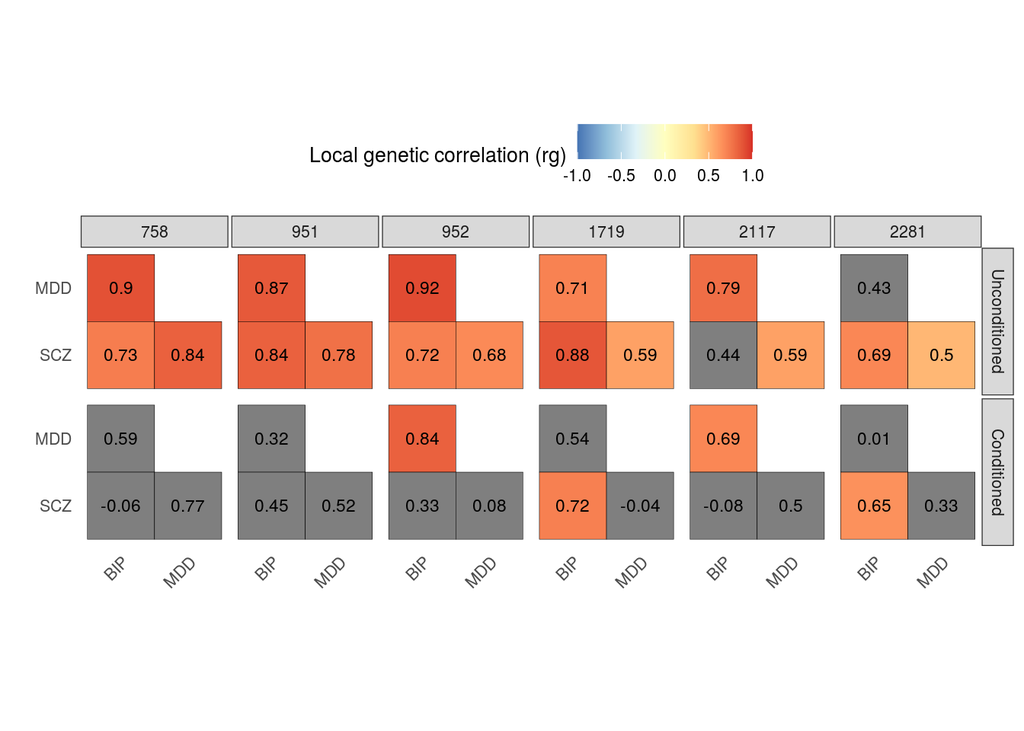

Figure 4.1: Heatmap demonstrating the effect of conditioning on a third neuropsychiatric phenotype when estimating the local genetic correlation between two neuropsychiatric phenotypes. The top heatmaps show the unconditioned bivariate local rg, while the bottom heatmaps show the partial bivariate local rgs conditioned on the neuropsychiatric phenotype that is not within the bivariate relationship (e.g. MDD and BIP conditioned on SCZ). The significance threshold for unconditioned bivariate local rgs was set to p < 0.05/n_bivar_tests, while for conditioned bivariate local rgs it was set to p < 0.05. Significant negative and positive correlations are indicated by blue and red fill, respectively. Non-significant correlations have a grey fill.

```r
bivar_results <-
  readRDS(
    list.files(
      here::here("results", "02_univar_bivar_test"),
      pattern = "bivar.lava.rds",
      full.names = T
    )
  ) %>%
  purrr::discard(is.null) %>%
  qdapTools::list_df2df() %>%
  dplyr::select(-X1)

data_to_plot <-
  pcorr %>%
  dplyr::filter(!is.na(pcor)) %>%
  dplyr::select(
    locus, phen1, phen2, pcor, p_cond = p
  ) %>%
  dplyr::inner_join(
    bivar_results %>%
      dplyr::select(
        locus, contains("phen"), rho, p_uncond = p
      ),
    by = c("locus", "phen1", "phen2")
  ) %>%
  tidyr::pivot_longer(
    cols = c("pcor", "p_cond", "rho", "p_uncond")
  ) %>%
  dplyr::mutate(
    model =
      case_when(
        name %in% c("pcor", "p_cond") ~ "Conditioned",
        TRUE ~ "Unconditioned"
      ) %>%
      fct_rev(),
    coef =
      case_when(
        name %in% c("pcor", "rho") ~ "corr",
        TRUE ~ "p"
      )
  ) %>%
  dplyr::select(-name) %>%
  tidyr::pivot_wider(
    names_from = c("coef"),
    values_from = c("value")
  )

data_to_plot %>%
  dplyr::mutate(
    rg_fill =
      dplyr::case_when(
        # Different p-value cut-offs depending on conditioning
        p < 0.05 & model == "Conditioned" ~ round(corr, 2),
        p < 0.05/nrow(bivar_results) & model == "Unconditioned" ~ round(corr, 2)
      ),
    p1 = phen1 %>%
      stringr::str_replace_all("[:digit:]", "") %>%
      stringr::str_remove("\\..*"),
    p2 = phen2 %>%
      stringr::str_replace_all("[:digit:]", "") %>%
      stringr::str_remove("\\..*")
  ) %>%
  ggplot2::ggplot(
    ggplot2::aes(
      x = p1,
      y = p2 %>% fct_rev(),
      fill = rg_fill,
      label = round(corr, 2)
    )
  ) +
  ggplot2::geom_tile(colour = "black") +
  ggplot2::geom_text(
    size = 3
  ) +
  ggplot2::facet_grid(rows = vars(model), cols = vars(locus)) +
  ggplot2::coord_fixed() +
  ggplot2::labs(x = "", y = "", fill = "Local genetic correlation (rg)") +
  ggplot2::scale_fill_distiller(
    palette = "RdYlBu",
    limits = c(-1, 1)
  ) +
  ggplot2::scale_colour_manual(values = c("black", "white")) +
  ggplot2::guides(colour = F) +
  theme_rhr +
  ggplot2::theme(
    panel.border = element_blank(),
    panel.grid = element_blank(),
    axis.ticks = element_blank()
  )
```

## 4.2 Multiple regression

### 4.2.1 Text

- A total of 14 models were constructed and run. This included 3 LD blocks where where all 3 neuropsychiatric traits were correlated with one another, and thus could arguably be the outcome trait.
- Of the 8 LD blocks that were (i) associated with > 1 trait pair and (ii) had a trait in common across trait pair associations, only 5 LD blocks contained an outcome ~ predictor model where >= 1 predictor trait significantly contributed to the local heritability of the outcome trait (Figure 4.2).
- All LD blocks modelling a neuropsychiatric phenotype using other neuropsychiatric phenotypes as predictors had very high multivariate $r^2$, with upper confidence intervals including 1 (Figure 4.2). This suggests that, for these LD blocks, the proportion of local heritability for the neuropsychiatric outcome is not independent of the predictor phenotypes.
- In contrast, the multivariate $r^2$ in LD block 2351, which was modelled with LBD as the outcome and AD and PD as predictors, was 0.43 (95% confidence interval: 0.38-0.5). Thus, while AD and PD jointly explained 43% of the local heritability of LBD, there was also a proportion of the local heritability for LBD which was independent of AD and PD.
- As observed in bivariate correlations, AD is positively associated with LBD, while PD is negatively associated.

### 4.2.2 Table

```r
print("Multiple regression column descriptions:")
```

```
## [1] "Multiple regression column descriptions:"
```

```r
tibble(
  column = colnames(multireg),
  description =
    c(
      "LD block ID",
      "For multiple regressions with multiple intermediate models, this is a model identifier",
      "Whether the regression model is an intermediate or full model",
      "Outcome phenotype",
      "Predictor phenotype",
      "Standardised multiple regression coefficient",
      "Lower bound of 95% confidence interval for gamma",
      "Upper bound of 95% confidence interval for gamma",
      "Proportion of variance in genetic signal for the outcome phenotype explained by all predictor phenotypes simultaneously",
      "Lower bound of 95% confidence interval for r2",
      "Upper bound of 95% confidence interval for r2",
      "Simulation p-values for the gammas"
    )
) %>%
  DT::datatable(rownames = FALSE,
                options = list(scrollX = TRUE),
                class = 'white-space: nowrap')
```

| column | description |
| --- | --- |
| locus | LD block ID |
| model_number | For multiple regressions with multiple intermediate models, this is a model identifier |
| model_type | Whether the regression model is an intermediate or full model |
| outcome | Outcome phenotype |
| predictors | Predictor phenotype |
| gamma | Standardised multiple regression coefficient |
| gamma.lower | Lower bound of 95% confidence interval for gamma |
| gamma.upper | Upper bound of 95% confidence interval for gamma |
| r2 | Proportion of variance in genetic signal for the outcome phenotype explained by all predictor phenotypes simultaneously |
| r2.lower | Lower bound of 95% confidence interval for r2 |

[output cut: 2 more lines]

```r
print("Multiple regression (all results):")
```

```
## [1] "Multiple regression (all results):"
```

```r
multireg %>%
  DT::datatable(rownames = FALSE,
                options = list(scrollX = TRUE),
                class = 'white-space: nowrap')
```

| locus | model_number | model_type | outcome | predictors | gamma | gamma.lower | gamma.upper | r2 | r2.lower | r2.upper | p |
| --- | --- | --- | --- | --- | --- | --- | --- | --- | --- | --- | --- |
| 758 | L1 | full | BIP2021 | MDD2019 | 1.00078 | -6.97447 | 9.3846 | 0.817572 | 0 | 1 | 0.249023 |
| 758 | L1 | full | BIP2021 | SCZ2018 | -0.117197 | -8.45473 | 7.88514 | 0.817572 | 0 | 1 | 0.890645 |
| 758 | L1 | full | MDD2019 | BIP2021 | 0.613346 | -0.55883 | 2.54594 | 0.888196 | 0.47788 | 1 | 0.205079 |
| 758 | L1 | full | MDD2019 | SCZ2018 | 0.39739 | -1.4579 | 1.53803 | 0.888196 | 0.47788 | 1 | 0.371327 |
| 758 | L1 | full | SCZ2018 | BIP2021 | -0.182027 | -6.23076 | 7.30542 | 0.71666 | 0 | 1 | 0.85797 |
| 758 | L1 | full | SCZ2018 | MDD2019 | 1.00709 | -6.5567 | 7.11384 | 0.71666 | 0 | 1 | 0.267141 |
| 951 | L1 | full | BIP2021 | MDD2019 | 0.562846 | -0.18736 | 2.07703 | 0.8235 | 0.58844 | 1 | 0.156896 |
| 951 | L1 | full | BIP2021 | SCZ2018 | 0.396143 | -1.11137 | 1.10571 | 0.8235 | 0.58844 | 1 | 0.311244 |
| 951 | L1 | full | MDD2019 | BIP2021 | 0.725777 | -1.0175 | 3.92221 | 0.772407 | 0.45749 | 1 | 0.192362 |
| 951 | L1 | full | MDD2019 | SCZ2018 | 0.176439 | -3.04061 | 1.88231 | 0.772407 | 0.45749 | 1 | 0.711239 |

[output cut: 25 more lines]

### 4.2.3 Figures

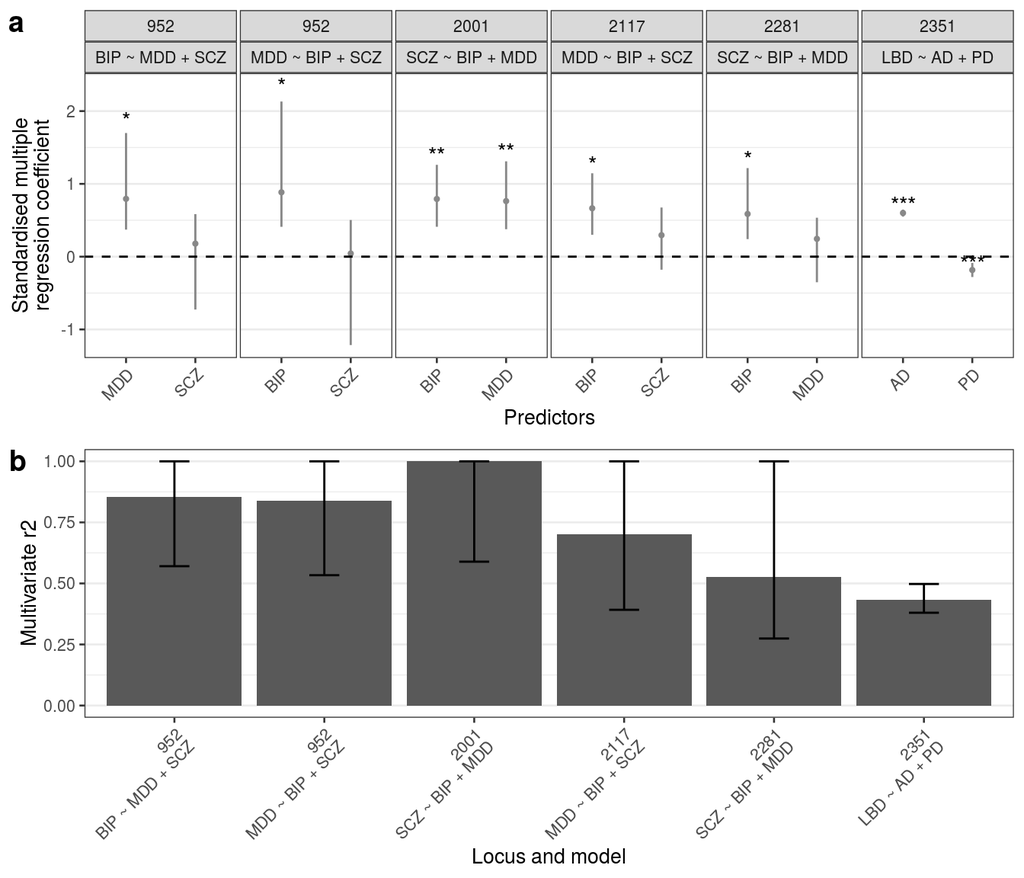

Figure 4.2: Results for multiple regression models across LD blocks with significant bivariate results between a phenotype and at least 2 others. For both plots, only those multiple regression models with at least one significant predictor (p < 0.05) are shown. (a) Plots of standardised coefficients for each predictor in multiple regression models across several LD blocks, with whiskers spanning the 95% confidence interval for the coefficients. (b) Mulivariate r2 for each LD block and model, where multivariate r2 represents the proportion of variance in genetic signal for the outcome phenotype explained by all predictor phenotypes simultaneously. Whiskers span the 95% confidence interval for the r2. 3 asterisks, p < 0.001; 2 asterisks, p < 0.01; 1 asterisk, p < 0.05.

```r
multireg_w_signif_pred <-
  multireg %>%
  dplyr::filter(
    p < 0.05,
    # locus %in% c(2281,2351)
  ) %>%
  dplyr::select(locus, contains("model"), outcome) %>%
  dplyr::distinct()

data_to_plot <-
  multireg_w_signif_pred %>%
  dplyr::inner_join(
    multireg,
    c("locus", "model_number", "model_type", "outcome")
  ) %>%
  dplyr::mutate(
    predictors = predictors %>%
      stringr::str_replace_all("[:digit:]", "") %>%
      stringr::str_remove("\\..*"),
    outcome = outcome %>%
      stringr::str_replace_all("[:digit:]", "") %>%
      stringr::str_remove("\\..*"),
    p_text = case_when(
      p < 0.001 ~ "***",
      p < 0.01 ~ "**",
      p < 0.05 ~ "*"
    ),
    locus =
      as.numeric(locus)
  )

data_to_plot <-
  data_to_plot %>%
  dplyr::inner_join(
    data_to_plot %>%
      dplyr::group_by(outcome, locus) %>%
      dplyr::summarise(predictors = str_c(predictors, collapse = " + ")) %>%
      dplyr::mutate(model = str_c(outcome, " ~ ", predictors)) %>%
      dplyr::select(outcome, locus, model)
  )

a <-
  data_to_plot %>%
  ggplot2::ggplot(
    ggplot2::aes(
      x = predictors,
      y = gamma,
      ymin = gamma.lower,
      ymax = gamma.upper
      )
    ) +
  ggplot2::geom_pointrange(
    colour = "#888888", fatten = 0.25
    ) +
  ggplot2::geom_hline(yintercept = 0, linetype = "dashed") +
  ggplot2::geom_text(
    aes(
      y = gamma.upper + (0.1 * gamma.upper),
      label = p_text
      )
    ) +
  ggplot2::facet_wrap(
    vars(locus, model),
    scales = "free_x",
    nrow = 1
    ) +
  ggplot2::labs(x = "Predictors", y = "Standardised multiple\nregression coefficient") +
  theme_rhr

b <-
    data_to_plot %>%
  dplyr::mutate(
    locus_model =
      str_c(locus, model, sep = "\n")
  ) %>%
  dplyr::distinct(
    locus, locus_model, r2, r2.lower, r2.upper
  ) %>%
  ggplot2::ggplot(
    ggplot2::aes(
      x = locus_model %>%
        fct_reorder(., .x = as.numeric(locus), .fun = max),
      y = r2,
      ymin = r2.lower,
      ymax = r2.upper
    )
  ) +
  geom_col() +
  geom_errorbar(width=.2) +
  labs(
    x = "Locus and model",
    y = "Multivariate r2"
  ) +
  theme_rhr


plot <-
  cowplot::plot_grid(
    a,b,
    ncol = 1,
    axis = "lr",
    align = "v",
    labels = letters[1:2]
  )

plot
```

# 5 Session info

**Show/hide**